# Ranking with TPM vs Count inputs with or without shrinkage

Mira Sohn

## Raw data

#### - **Link**: https://www.ncbi.nlm.nih.gov/geo/query/acc.cgi?acc=GSE157852

#### - **Study aim**: Reveal neurological complications in patients with COVID-19

#### - **Study summary**: Human Pluripotent Stem Cell-Derived Neural Cells and Brain Organoids were infected with SARS-CoV-2 for 72hrs and analyzed with bulk RNA-seq.

#### - Samples: Mock- or SARS-CoV-2-infected neuronal cells

## Loading packages

```r
library(data.table)
library(rmarkdown)
library(AnnotationHub)
library(tidyverse)
library(tximport)
library(ggplot2)
library(DESeq2)
library(UpSetR)
```

## Setting AnnotationHub

```r
AnnotationSpecies <- "Homo sapiens"  # Assign your species
ah <- AnnotationHub(hub=getAnnotationHubOption("URL"))   # Bring annotation DB
```

## Running AnnotationHub

```r
ahQuery <- query(ah, c("OrgDb", AnnotationSpecies))      # Filter annotation of interest

if (length(ahQuery) == 1) {
    DBName <- names(ahQuery)
} else if (length(ahQuery) > 1) {
               DBName <- names(ahQuery)[1]
} else {
    print("You don't have a valid DB")
    rmarkdown::render()
}

AnnoDb <- ah[[DBName]] # Store into an OrgDb object

# Explore your OrgDb object with following accessors:
# columns(AnnpDb)
# keytypes(AnnoDb)
# keys(AnnoDb, keytype=..)
# select(AnnoDb, keys=.., columns=.., keytype=...)
AnnoKey <- keys(AnnoDb, keytype="ENSEMBLTRANS")

# Note: Annotation has to be done with not genome but transcripts
AnnoDb <- select(AnnoDb,
                 AnnoKey,
                 keytype="ENSEMBLTRANS",
                 columns="ENSEMBL")

# Check if your AnnoDb has been extracted and saved correctely
class(AnnoDb)
```

```
## [1] "data.frame"
```

```r
head(AnnoDb)
```

```
##      ENSEMBLTRANS         ENSEMBL
## 1 ENST00000543404 ENSG00000256069
## 2 ENST00000566278 ENSG00000256069
## 3 ENST00000545343 ENSG00000256069
## 4 ENST00000544183 ENSG00000256069
## 5 ENST00000286479 ENSG00000156006
## 6 ENST00000520116 ENSG00000156006
```

## Defining file name and path for .sf files

#### .sf files have been created from fastq data by salmon

```r
# This code chunk needs to be revised by yourself

# Define sample names
SampleNames <-  c("Mock_72hpi_S1",
                 "Mock_72hpi_S2",
                 "Mock_72hpi_S3",
                 "SARS-CoV-2_72hpi_S7",
                 "SARS-CoV-2_72hpi_S8",
                 "SARS-CoV-2_72hpi_S9")

# Define group level
GroupLevel <- c("Mock", "COVID")

# Define contrast for DE analysis
Contrast <- c("Group", "COVID", "Mock")

# Define a vector for comparing TPM vs Counts effect
TvC <- c("TPM", "Counts")

# Define .sf file path
sf <- c(paste0(SampleNames,
               ".salmon_quant/quant.sf"))

# Define sample groups
group <- c(rep("Mock", 3), rep("COVID", 3))

# Create metadata
metadata <- data.frame(Sample=factor(SampleNames, levels=SampleNames),
                       Group=factor(group, levels=GroupLevel),
                       Path=sf)

rownames(metadata) <- SampleNames

# Explore the metadata
print(metadata)
```

```
##                                  Sample Group
## Mock_72hpi_S1             Mock_72hpi_S1  Mock
## Mock_72hpi_S2             Mock_72hpi_S2  Mock
## Mock_72hpi_S3             Mock_72hpi_S3  Mock
## SARS-CoV-2_72hpi_S7 SARS-CoV-2_72hpi_S7 COVID
## SARS-CoV-2_72hpi_S8 SARS-CoV-2_72hpi_S8 COVID
## SARS-CoV-2_72hpi_S9 SARS-CoV-2_72hpi_S9 COVID
##                                                          Path
## Mock_72hpi_S1             Mock_72hpi_S1.salmon_quant/quant.sf
## Mock_72hpi_S2             Mock_72hpi_S2.salmon_quant/quant.sf
## Mock_72hpi_S3             Mock_72hpi_S3.salmon_quant/quant.sf
## SARS-CoV-2_72hpi_S7 SARS-CoV-2_72hpi_S7.salmon_quant/quant.sf
## SARS-CoV-2_72hpi_S8 SARS-CoV-2_72hpi_S8.salmon_quant/quant.sf
## SARS-CoV-2_72hpi_S9 SARS-CoV-2_72hpi_S9.salmon_quant/quant.sf
```

## Converting .sf files to txi list

#### - txi_tpm: stores **TPM** with the argument **“countsFromAbundance=”lengthScaledTPM"**

#### - txi_counts: stores **original counts**

#### - Despite that the TPM matrix is not recommended as an input for DE analysis due to the fact that it doesn’t account gene length, TPM stored in a tximport (by **tximport(…, countsFromAbundance=“lengthScaledTPM”)**) can be used for DE analysis by being inputted with the **DESeqDataSetFromTximport()** funtion in DESeq2 workflow as the gene length is automatically adjusted by DESeqDataSetFromTximport().

#### - In this project, two txi objects were created with or without the countsFromAbundance=“lengthScaledTPM” argument and compared in downstream DE analysis.

#### - If you don’t want gene-level summarization, set **txOut=TRUE**.

#### - References: [**tximport doc**](https://bioconductor.riken.jp/packages/3.4/bioc/vignettes/tximport/inst/doc/tximport.html), [**DESeq2 doc “Why unnormalized counts?”**](https://www.bioconductor.org/packages/devel/bioc/vignettes/DESeq2/inst/doc/DESeq2.html#why-un-normalized-counts), [**Soneson et al. 2016**](https://www.ncbi.nlm.nih.gov/pmc/articles/PMC4712774/), [**Developer Dr. Love’s comment**](https://support.bioconductor.org/p/84059/), [**Harvard Chan Bioinformatics Core workshop**](https://github.com/hbctraining/DGE_workshop_salmon_online/blob/master/lessons/02_DGE_count_normalization.md)

```r
# Assign sample names to the input (.sf) file path
names(sf) <- SampleNames

# Run tximport
# tpm vs original counts
# input sf: a factor of all .sf files' path
txi_tpm <- tximport(sf,
                    type="salmon",
                    tx2gene=AnnoDb,
                    countsFromAbundance="lengthScaledTPM", # Extracts TPM
                    ignoreTxVersion=T)

txi_counts <- tximport(sf,
                    type="salmon",
                    tx2gene=AnnoDb,
                    ignoreTxVersion=T)
```

## Exploring the txi outputs

```r
# tpm
head(txi_tpm$counts)
```

```
##                 Mock_72hpi_S1 Mock_72hpi_S2 Mock_72hpi_S3 SARS-CoV-2_72hpi_S7
## ENSG00000000005      7.070765     3.9553384      0.000000            2.005611
## ENSG00000001561   2869.067773  2815.4099024   2505.840041         2441.570571
## ENSG00000002933     15.834261    29.9496544     20.299681           23.812625
## ENSG00000003056   1377.763530  1455.2367094   1409.363877         2235.241372
## ENSG00000003137      6.937959     0.9778637      4.079638            2.004542
## ENSG00000004478    310.234206   359.0975793    241.072871          322.347144
##                 SARS-CoV-2_72hpi_S8 SARS-CoV-2_72hpi_S9
## ENSG00000000005            0.991471            3.995875
## ENSG00000001561         1118.560306         2063.758243
## ENSG00000002933           16.175788           22.454731
## ENSG00000003056         1262.765572         1344.970721
## ENSG00000003137            0.000000            3.958398
## ENSG00000004478          249.533585          256.177316
```

```r
dim(txi_tpm$counts)
```

```
## [1] 12202     6
```

```r
# counts
head(txi_counts$counts)
```

```
##                 Mock_72hpi_S1 Mock_72hpi_S2 Mock_72hpi_S3 SARS-CoV-2_72hpi_S7
## ENSG00000000005         7.000         4.000         0.000               2.000
## ENSG00000001561      2889.000      2782.000      2515.000            2498.000
## ENSG00000002933        17.000        32.000        18.000              25.000
## ENSG00000003056      1423.239      1538.872      1321.746            2218.899
## ENSG00000003137         7.000         1.000         4.000               2.000
## ENSG00000004478       277.060       305.784       224.861             378.570
##                 SARS-CoV-2_72hpi_S8 SARS-CoV-2_72hpi_S9
## ENSG00000000005               1.000               4.000
## ENSG00000001561            1102.000            2073.000
## ENSG00000002933              14.000              24.000
## ENSG00000003056            1274.681            1318.380
## ENSG00000003137               0.000               4.000
## ENSG00000004478             237.273             310.415
```

```r
dim(txi_counts$counts)
```

```
## [1] 12202     6
```

## Creating DESeq objects from txi and VST

#### - Note: The tximport-to-DESeq2 approach uses estimated gene counts from the transcript abundance quantifiers, but not normalized counts.

#### - The **DESeqDataSetFromTximport()** function generated an DESeq object (aka **dds**) with the **txi input**.

#### - References: [**DESeq2 doc “Transcript abundance files”**](https://www.bioconductor.org/packages/devel/bioc/vignettes/DESeq2/inst/doc/DESeq2.html#tximport), [**DESeq2 doc “Variance stabilizing transformation”**](https://www.bioconductor.org/packages/devel/bioc/vignettes/DESeq2/inst/doc/DESeq2.html#variance-stabilizing-transformation)

```r
# Initialize a list storing dds object
desList <- list()

for (x in TvC) {

    if (x == TvC[1]) {

        desList[[x]] <- DESeqDataSetFromTximport(txi_tpm,
                                    colData=metadata,
                                    design=~Group)
    } else {

        desList[[x]] <- DESeqDataSetFromTximport(txi_counts,
                                    colData=metadata,
                                    design=~Group)

    }
}

# Exploring created dds
# TPM
desList[[TvC[1]]]
```

```
## class: DESeqDataSet
## dim: 12202 6
## metadata(1): version
## assays(1): counts
## rownames(12202): ENSG00000000005 ENSG00000001561 ... ENSG00000288631
##   ENSG00000288642
## rowData names(0):
## colnames(6): Mock_72hpi_S1 Mock_72hpi_S2 ... SARS-CoV-2_72hpi_S8
##   SARS-CoV-2_72hpi_S9
## colData names(3): Sample Group Path
```

```r
head(counts(desList[[TvC[1]]]))
```

```
##                 Mock_72hpi_S1 Mock_72hpi_S2 Mock_72hpi_S3 SARS-CoV-2_72hpi_S7
## ENSG00000000005             7             4             0                   2
## ENSG00000001561          2869          2815          2506                2442
## ENSG00000002933            16            30            20                  24
## ENSG00000003056          1378          1455          1409                2235
## ENSG00000003137             7             1             4                   2
## ENSG00000004478           310           359           241                 322
##                 SARS-CoV-2_72hpi_S8 SARS-CoV-2_72hpi_S9
## ENSG00000000005                   1                   4
## ENSG00000001561                1119                2064
## ENSG00000002933                  16                  22
## ENSG00000003056                1263                1345
## ENSG00000003137                   0                   4
## ENSG00000004478                 250                 256
```

```r
# Counts
desList[[TvC[2]]]
```

```
## class: DESeqDataSet
## dim: 12202 6
## metadata(1): version
## assays(2): counts avgTxLength
## rownames(12202): ENSG00000000005 ENSG00000001561 ... ENSG00000288631
##   ENSG00000288642
## rowData names(0):
## colnames(6): Mock_72hpi_S1 Mock_72hpi_S2 ... SARS-CoV-2_72hpi_S8
##   SARS-CoV-2_72hpi_S9
## colData names(3): Sample Group Path
```

```r
head(counts(desList[[TvC[2]]]))
```

```
##                 Mock_72hpi_S1 Mock_72hpi_S2 Mock_72hpi_S3 SARS-CoV-2_72hpi_S7
## ENSG00000000005             7             4             0                   2
## ENSG00000001561          2889          2782          2515                2498
## ENSG00000002933            17            32            18                  25
## ENSG00000003056          1423          1539          1322                2219
## ENSG00000003137             7             1             4                   2
## ENSG00000004478           277           306           225                 379
##                 SARS-CoV-2_72hpi_S8 SARS-CoV-2_72hpi_S9
## ENSG00000000005                   1                   4
## ENSG00000001561                1102                2073
## ENSG00000002933                  14                  24
## ENSG00000003056                1275                1318
## ENSG00000003137                   0                   4
## ENSG00000004478                 237                 310
```

## Estimating size factors, dispersions, and conducting Wald Test

#### - **Dispersion** is calculated as a **measure of variation** instead of variance since variance gets larger when gene expression gets higher.

#### - **Wald test** is the default setting of DESeq2 which tests null hypothesis between **two groups**. You should use **Likelihood ratio test (LRT)** when comparing **more than two groups**.

#### - Messages when “Counts <- DESeqPrep_fn(Counts)” was run:

using **‘avgTxLength’** from assays(dds), correcting for library size gene-wise dispersion estimates mean-dispersion relationship final dispersion estimates

#### - References: [**Harvard Chan Bioinformatics Core workshop I**](https://github.com/hbctraining/DGE_workshop_salmon_online/blob/master/lessons/05b_wald_test_results.md), [**Harvard Chan Bioinformatics Core workshop II**](https://github.com/hbctraining/DGE_workshop_salmon_online/blob/master/lessons/05a_hypothesis_testing.md), [**Harvard Chan Bioinformatics Core workshop III**](https://github.com/hbctraining/DGE_workshop_salmon_online/blob/master/lessons/04b_DGE_DESeq2_analysis.md), [**DESeq2 "Wald test indivisual steps**](https://www.bioconductor.org/packages/devel/bioc/vignettes/DESeq2/inst/doc/DESeq2.html#wald-test-individual-steps), [**DESeq2 doc “Likelihood ratio test”**](https://www.bioconductor.org/packages/devel/bioc/vignettes/DESeq2/inst/doc/DESeq2.html#likelihood-ratio-test)

```r
# Update dds

for (x in TvC) {

    desList[[x]] <- estimateSizeFactors(desList[[x]])
    desList[[x]] <- estimateDispersions(desList[[x]])
    desList[[x]] <- nbinomWaldTest(desList[[x]])
}

# Explore the updates
desList
```

```
## $TPM
## class: DESeqDataSet
## dim: 12202 6
## metadata(1): version
## assays(4): counts mu H cooks
## rownames(12202): ENSG00000000005 ENSG00000001561 ... ENSG00000288631
##   ENSG00000288642
## rowData names(22): baseMean baseVar ... deviance maxCooks
## colnames(6): Mock_72hpi_S1 Mock_72hpi_S2 ... SARS-CoV-2_72hpi_S8
##   SARS-CoV-2_72hpi_S9
## colData names(4): Sample Group Path sizeFactor
##
## $Counts
## class: DESeqDataSet
## dim: 12202 6
## metadata(1): version
## assays(6): counts avgTxLength ... H cooks
## rownames(12202): ENSG00000000005 ENSG00000001561 ... ENSG00000288631
##   ENSG00000288642
## rowData names(22): baseMean baseVar ... deviance maxCooks
## colnames(6): Mock_72hpi_S1 Mock_72hpi_S2 ... SARS-CoV-2_72hpi_S8
##   SARS-CoV-2_72hpi_S9
## colData names(3): Sample Group Path
```

## Running DE analysis without shrinkage

```r
# Create a list for TPM and Counts dds
ddsList <- desList  # DE without shrinkage

for (x in TvC) {

    # Run DESeq()
    ddsList[[x]] <- DESeq(desList[[x]])
    print(resultsNames(ddsList[[x]]))


}
```

```
## [1] "Intercept"           "Group_COVID_vs_Mock"
## [1] "Intercept"           "Group_COVID_vs_Mock"
```

## Extracting DE results with or without shrinkage

#### - The **alpha** denotes threshold of **false discovery rate (FDR)** assigned by users.

#### - In this analysis, the alpha is set to **0.1**

```r
# Set FDR threshold
alpha=0.1

# FDR threshold vector
FDRv=c(paste("<",  alpha),
       paste(">",  alpha))

# Initialize lists of result tables
resList <- ddsList

# Set a function cleaning table
Sig.fn <- function(df, Input) {

    df <- df %>%
        rownames_to_column(var="Gene") %>%
        mutate(FDR=ifelse(padj < 0.1 & !is.na(padj),
                                   FDRv[1],
                                   FDRv[2]),
               Input=Input)
    return(df)
}


for (x in TvC) {

        # Extract data frames from unshrunken lfc & clean data
        resList[[x]] <- as.data.frame(results(ddsList[[x]],
                                              contrast=Contrast,
                                              alpha=alpha)) %>% Sig.fn(x)

         }





# Explore the results
summary(resList)
```

```
##        Length Class      Mode
## TPM    9      data.frame list
## Counts 9      data.frame list
```

```r
head(resList[[TvC[1]]])
```

```
##              Gene    baseMean log2FoldChange     lfcSE       stat       pvalue
## 1 ENSG00000000005    2.812239     -0.5995206 1.6210673 -0.3698308 7.115086e-01
## 2 ENSG00000001561 2233.314621     -0.6102747 0.1463362 -4.1703616 3.041167e-05
## 3 ENSG00000002933   20.984891     -0.1226327 0.5748728 -0.2133215 8.310762e-01
## 4 ENSG00000003056 1473.676594      0.1319750 0.1496943  0.8816298 3.779770e-01
## 5 ENSG00000003137    2.872157     -1.0856990 1.6130486 -0.6730728 5.009010e-01
## 6 ENSG00000004478  285.043360     -0.1360211 0.2073809 -0.6558998 5.118886e-01
##           padj   FDR Input
## 1           NA > 0.1   TPM
## 2 0.0006745881 < 0.1   TPM
## 3 0.9644148113 > 0.1   TPM
## 4 0.7637602188 > 0.1   TPM
## 5           NA > 0.1   TPM
## 6 0.8554112644 > 0.1   TPM
```

```r
head(resList[[TvC[2]]])
```

```
##              Gene    baseMean log2FoldChange     lfcSE       stat       pvalue
## 1 ENSG00000000005    2.856834     -0.6046863 1.5944126 -0.3792533 7.044997e-01
## 2 ENSG00000001561 2268.078396     -0.6117570 0.1470241 -4.1609303 3.169538e-05
## 3 ENSG00000002933   21.348008     -0.1141621 0.5676215 -0.2011237 8.406018e-01
## 4 ENSG00000003056 1495.425091      0.1306716 0.1501323  0.8703764 3.840947e-01
## 5 ENSG00000003137    2.911977     -1.0919647 1.5877523 -0.6877425 4.916150e-01
## 6 ENSG00000004478  287.000260     -0.1412010 0.2059217 -0.6857022 4.929009e-01
##           padj   FDR  Input
## 1           NA > 0.1 Counts
## 2 0.0006976803 < 0.1 Counts
## 3 0.9607285073 > 0.1 Counts
## 4 0.7630895690 > 0.1 Counts
## 5           NA > 0.1 Counts
## 6 0.8416167965 > 0.1 Counts
```

## Exploring mean-difference relationship with MA plots

#### - **x-axis**: expression level (baseMean))

#### - **y-axis**: fold change (log2FoldChange)

#### - **Red dashed lines**: log2FoldChange = -1 and 1

#### - Reference: [**DESeq2 doc “MA-plot”**](https://www.bioconductor.org/packages/devel/bioc/vignettes/DESeq2/inst/doc/DESeq2.html#ma-plot)

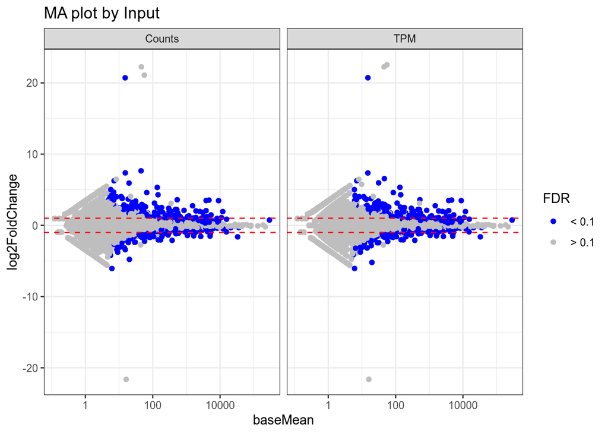

```r
# Set min log2 fold change of interest
mLog <- c(-1, 1)


# Create an input data frame for MA plots
both.df <- rbind(resList[[TvC[1]]], resList[[2]])

# Create MA plots
ggplot(both.df,
       aes(x=baseMean, y=log2FoldChange, color=FDR)) +
geom_point() + scale_x_log10() + facet_grid(~Input) +
theme_bw() + scale_color_manual(values=c("blue", "grey")) +
ggtitle(paste("MA plot by Input")) + geom_hline(yintercept=c(mLog[1], mLog[2]), linetype="dashed", color="red")
```

## Exploring distribution of log2FoldChange by input type

#### - Black dashed lines: log2FoldChange = -1 and 1

#### - **x-axis**: gene expression level (log2FoldChange)

#### - **y-axis**: number of genes

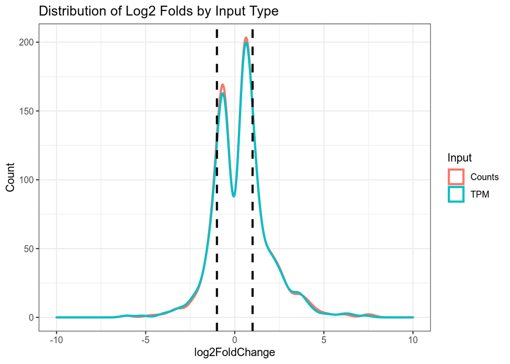

```r
# Create lfc distribution plots
ggplot(both.df[both.df$FDR == FDRv[1],],
       aes(x=log2FoldChange, color=Input)) +
geom_density(size=1, aes(y=..count..)) + theme_bw() + ylab("Count") + geom_vline(xintercept=c(mLog[1], mLog[2]), color="black", linetype="dashed", size=1) + ggtitle("Distribution of Log2 Folds by Input Type") +
xlim(-10, 10)
```

## NA statistics: zero count genes & outlier genes

#### - **log2FoldChange**: zero counts in all samples

#### - **padj**: too little information

#### - **pval & padj**: at least one replicate was an outlier

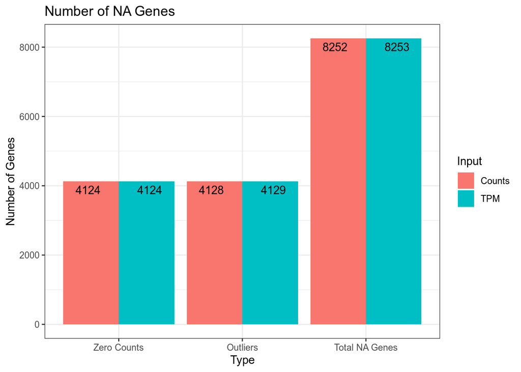

```r
# Count number of NA genes
type=c("Zero Counts", "Outliers", "Total NA Genes")

# Create a data frame storing number of NA genes by type
NA.genes <- both.df %>%
    group_by(Input) %>%
    summarize(zero=sum(is.na(log2FoldChange)),
              outlier=sum(is.na(pvalue) & is.na(padj))) %>%
    mutate(total=zero + outlier) %>%
    gather(Type, Number, -Input) %>%
    mutate(Type=factor(case_when(Type == "zero" ~ type[1],
                                 Type == "outlier" ~ type[2],
                                 Type == "total" ~ type[3]),
                       levels=type))

# Plot number of NA genes
ggplot(NA.genes,
       aes(x=Type, y=Number, group=Input, fill=Input, label=Number)) +
    geom_bar(stat="identity", position="dodge") +
    theme_bw() +
    geom_text(position=position_dodge(width=1), vjust=1.5) +
    ggtitle("Number of NA Genes") +
    ylab("Number of Genes")
```

## Ranking DEGs

#### - **fdr.rank**: ranked by FDR

#### - **lfc.rank**: ranked by absolute fold change

#### - **up.lfc.rank**: ranked by magnitude of fold change increase

#### - **down.lfc.rank**: ranked by manitude of fold change decrease

```r
# Create a new list having DE table with FDR below alpha
fdr.rank <- resList
lfc.rank <- resList
up.lfc.rank <- resList
down.lfc.rank <- resList

# Set a function cleaning a data frame
filter.fdr.fn <- function(df) {as.data.table(df[df$FDR == FDRv[1],])}

# Set a function creating a column for the rank
Ranking.fn <- function(x) {mutate(x, Rank=1:nrow(x))}



for (x in TvC) {

    rdf <- resList[[x]]

    fdr.rank[[x]] <- filter.fdr.fn(rdf) %>% arrange(padj) %>% Ranking.fn()

    lfc.rank[[x]] <- filter.fdr.fn(rdf) %>% arrange(desc(abs(log2FoldChange))) %>% Ranking.fn()

    up.lfc.rank[[x]] <- filter.fdr.fn(rdf) %>% arrange(desc(log2FoldChange)) %>% Ranking.fn()

    down.lfc.rank[[x]] <- filter.fdr.fn(rdf) %>% arrange(log2FoldChange) %>% Ranking.fn()

}

# Explore the ranking outputs
head(fdr.rank[[1]])
```

```
##               Gene   baseMean log2FoldChange     lfcSE     stat       pvalue
## 1: ENSG00000118523  3782.1546       3.486643 0.1950104 17.87927 1.710657e-71
## 2: ENSG00000181104  2460.4827       1.954674 0.1235420 15.82194 2.196087e-56
## 3: ENSG00000163814  1500.9144       2.752287 0.1916214 14.36315 8.812579e-47
## 4: ENSG00000211455 11846.6666       1.939965 0.1373091 14.12845 2.536811e-45
## 5: ENSG00000163762  1895.6825       2.030180 0.1457396 13.93019 4.152312e-44
## 6: ENSG00000138271   526.0495       3.595677 0.2633221 13.65505 1.883633e-42
##            padj   FDR Input Rank
## 1: 6.249030e-68 < 0.1   TPM    1
## 2: 4.011153e-53 < 0.1   TPM    2
## 3: 1.073078e-43 < 0.1   TPM    3
## 4: 2.316742e-42 < 0.1   TPM    4
## 5: 3.033679e-41 < 0.1   TPM    5
## 6: 1.146819e-39 < 0.1   TPM    6
```

```r
head(lfc.rank[[1]])
```

```
##               Gene  baseMean log2FoldChange     lfcSE      stat       pvalue
## 1: ENSG00000244398 15.010762      20.722648 3.9097498  5.300249 1.156447e-07
## 2: ENSG00000248167 14.963658       7.357277 1.3588280  5.414428 6.148483e-08
## 3: ENSG00000198796 46.264341       6.562879 1.5079611  4.352154 1.348067e-05
## 4: ENSG00000178776  7.009990       6.266813 1.6281884  3.848948 1.186261e-04
## 5: ENSG00000263647  6.033026      -6.053508 1.6148643 -3.748617 1.778121e-04
## 6: ENSG00000205277 31.299509       5.963490 0.9954338  5.990845 2.087531e-09
##            padj   FDR Input Rank
## 1: 4.912212e-06 < 0.1   TPM    1
## 2: 2.739074e-06 < 0.1   TPM    2
## 3: 3.282993e-04 < 0.1   TPM    3
## 4: 2.155927e-03 < 0.1   TPM    4
## 5: 3.007166e-03 < 0.1   TPM    5
## 6: 1.229960e-07 < 0.1   TPM    6
```

```r
head(up.lfc.rank[[1]])
```

```
##               Gene  baseMean log2FoldChange     lfcSE     stat       pvalue
## 1: ENSG00000244398  15.01076      20.722648 3.9097498 5.300249 1.156447e-07
## 2: ENSG00000248167  14.96366       7.357277 1.3588280 5.414428 6.148483e-08
## 3: ENSG00000198796  46.26434       6.562879 1.5079611 4.352154 1.348067e-05
## 4: ENSG00000178776   7.00999       6.266813 1.6281884 3.848948 1.186261e-04
## 5: ENSG00000205277  31.29951       5.963490 0.9954338 5.990845 2.087531e-09
## 6: ENSG00000137673 134.20635       5.338582 1.1062628 4.825781 1.394554e-06
##            padj   FDR Input Rank
## 1: 4.912212e-06 < 0.1   TPM    1
## 2: 2.739074e-06 < 0.1   TPM    2
## 3: 3.282993e-04 < 0.1   TPM    3
## 4: 2.155927e-03 < 0.1   TPM    4
## 5: 1.229960e-07 < 0.1   TPM    5
## 6: 4.673676e-05 < 0.1   TPM    6
```

```r
head(down.lfc.rank[[1]])
```

```
##               Gene  baseMean log2FoldChange    lfcSE      stat       pvalue
## 1: ENSG00000263647  6.033026      -6.053508 1.614864 -3.748617 1.778121e-04
## 2: ENSG00000271723 19.770937      -5.205907 1.040842 -5.001629 5.684777e-07
## 3: ENSG00000261408  5.483008      -4.149457 1.544679 -2.686291 7.225009e-03
## 4: ENSG00000251177  8.961759      -3.762518 1.098125 -3.426312 6.118378e-04
## 5: ENSG00000205111  8.951564      -3.716447 1.143806 -3.249193 1.157328e-03
## 6: ENSG00000273540  6.489977      -3.209238 1.179382 -2.721119 6.506139e-03
##            padj   FDR Input Rank
## 1: 3.007166e-03 < 0.1   TPM    1
## 2: 2.185946e-05 < 0.1   TPM    2
## 3: 6.012063e-02 < 0.1   TPM    3
## 4: 8.563385e-03 < 0.1   TPM    4
## 5: 1.423474e-02 < 0.1   TPM    5
## 6: 5.637809e-02 < 0.1   TPM    6
```

## Calculating rank difference

```r
# Set a function rebuilding DE tables with gene ranks
rankdiff.fn <- function(List){

    # Select columns and join the data frames by gene
    full_join(List[[TvC[1]]][, .(Gene, Input, Rank, baseMean)],
              List[[TvC[2]]][, .(Gene, Input, Rank, baseMean)],
              by="Gene") %>%

    # Add columns assining gene expression levels, rank differences, and mean ranks
    mutate(logMeanExpression=log(baseMean.x+baseMean.y/2),
           RankDiff=Rank.x-Rank.y,
           MeanRank=(Rank.x+Rank.y)/2)
}

# Calculate rank difference by ranking type
fdr.rankdiff <- rankdiff.fn(fdr.rank)
lfc.rankdiff <- rankdiff.fn(lfc.rank)
up.lfc.rankdiff <- rankdiff.fn(up.lfc.rank)
down.lfc.rankdiff <- rankdiff.fn(down.lfc.rank)

# Explore the calculated rank differences
head(fdr.rankdiff)
```

```
##               Gene Input.x Rank.x baseMean.x Input.y Rank.y baseMean.y
## 1: ENSG00000118523     TPM      1  3782.1546  Counts      1  3838.8131
## 2: ENSG00000181104     TPM      2  2460.4827  Counts      2  2498.1179
## 3: ENSG00000163814     TPM      3  1500.9144  Counts      3  1523.3025
## 4: ENSG00000211455     TPM      4 11846.6666  Counts      4 12016.7778
## 5: ENSG00000163762     TPM      5  1895.6825  Counts      5  1919.1263
## 6: ENSG00000138271     TPM      6   526.0495  Counts      6   533.5471
##    logMeanExpression RankDiff MeanRank
## 1:          8.648495        0        1
## 2:          8.218664        0        2
## 3:          7.724255        0        3
## 4:          9.790042        0        4
## 5:          7.956913        0        5
## 6:          6.675600        0        6
```

```r
head(lfc.rankdiff)
```

```
##               Gene Input.x Rank.x baseMean.x Input.y Rank.y baseMean.y
## 1: ENSG00000244398     TPM      1  15.010762  Counts      1  15.154500
## 2: ENSG00000248167     TPM      2  14.963658  Counts      3  15.294288
## 3: ENSG00000198796     TPM      3  46.264341  Counts      2  44.935384
## 4: ENSG00000178776     TPM      4   7.009990  Counts      4   7.111688
## 5: ENSG00000263647     TPM      5   6.033026  Counts      5   6.129028
## 6: ENSG00000205277     TPM      6  31.299509  Counts      6  19.797258
##    logMeanExpression RankDiff MeanRank
## 1:          3.117419        0      1.0
## 2:          3.118428       -1      2.5
## 3:          4.230215        1      2.5
## 4:          2.357626        0      4.0
## 5:          2.208004        0      5.0
## 6:          3.718393        0      6.0
```

```r
head(up.lfc.rankdiff)
```

```
##               Gene Input.x Rank.x baseMean.x Input.y Rank.y baseMean.y
## 1: ENSG00000244398     TPM      1   15.01076  Counts      1  15.154500
## 2: ENSG00000248167     TPM      2   14.96366  Counts      3  15.294288
## 3: ENSG00000198796     TPM      3   46.26434  Counts      2  44.935384
## 4: ENSG00000178776     TPM      4    7.00999  Counts      4   7.111688
## 5: ENSG00000205277     TPM      5   31.29951  Counts      5  19.797258
## 6: ENSG00000137673     TPM      6  134.20635  Counts      6 136.082046
##    logMeanExpression RankDiff MeanRank
## 1:          3.117419        0      1.0
## 2:          3.118428       -1      2.5
## 3:          4.230215        1      2.5
## 4:          2.357626        0      4.0
## 5:          3.718393        0      5.0
## 6:          5.309492        0      6.0
```

```r
head(down.lfc.rankdiff)
```

```
##               Gene Input.x Rank.x baseMean.x Input.y Rank.y baseMean.y
## 1: ENSG00000263647     TPM      1   6.033026  Counts      1   6.129028
## 2: ENSG00000271723     TPM      2  19.770937  Counts      2  20.243254
## 3: ENSG00000261408     TPM      3   5.483008  Counts      3   5.565687
## 4: ENSG00000251177     TPM      4   8.961759  Counts      4   9.095538
## 5: ENSG00000205111     TPM      5   8.951564  Counts      6   8.565669
## 6: ENSG00000273540     TPM      6   6.489977    <NA>     NA         NA
##    logMeanExpression RankDiff MeanRank
## 1:          2.208004        0      1.0
## 2:          3.397610        0      2.0
## 3:          2.112133        0      3.0
## 4:          2.603395        0      4.0
## 5:          2.582819       -1      5.5
## 6:                NA       NA       NA
```

## Visualizing DEG ranks I: TPM- vs Counts-input

#### - **x-axis**: rank with TPM input

#### - **y-axis**: rank with Counts input

#### - Black diagonal lines: rank with TPM = rank with Counts

#### - Dot color: gene expression level (log-baseMean)

#### - 16 genes were missing in the plots

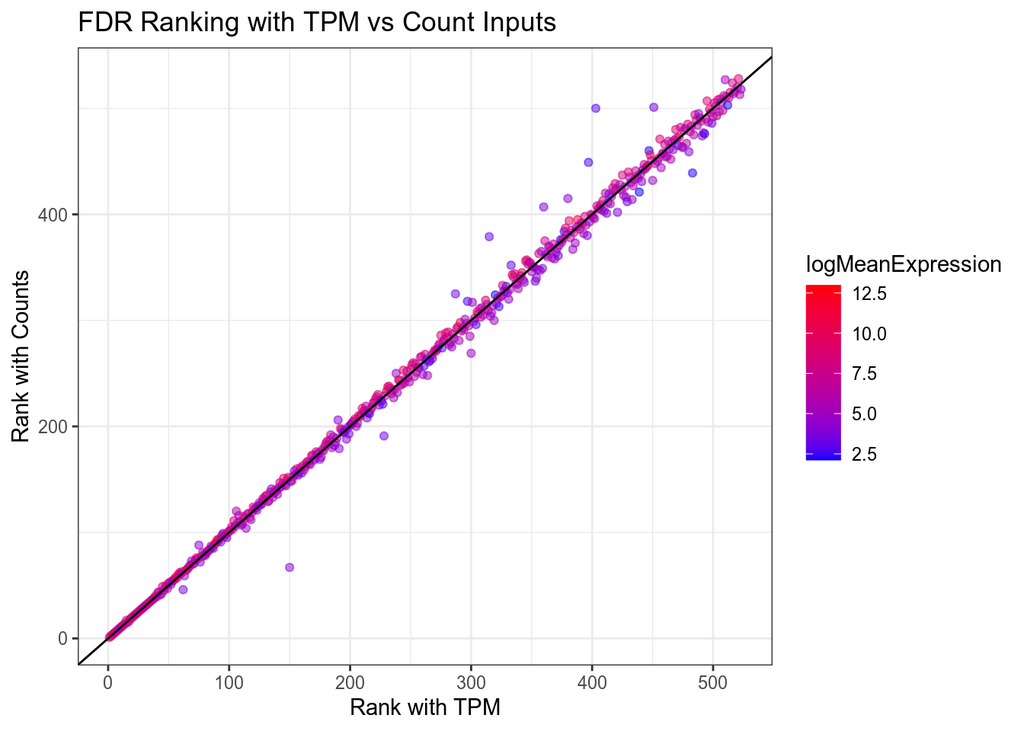

```r
# Set a function plotting gene ranks between TPM- (x-axis) and Counts-Inputs (y-axis)
ranking.plot.fn <- function(df, rankedby) {

    ggplot(df,
           aes(x=Rank.x, y=Rank.y, color=logMeanExpression)) + geom_point(alpha=0.5) + theme_bw() + theme(strip.text.x=element_text(size=10)) + xlab("Rank with TPM") + ylab("Rank with Counts") + geom_abline(slope=1, color="black", size=0.5) + ggtitle(paste(rankedby, "Ranking with TPM vs Count Inputs")) + scale_color_gradient(low="blue", high="red")
}

# Print output plots
ranking.plot.fn(fdr.rankdiff, "FDR")
```

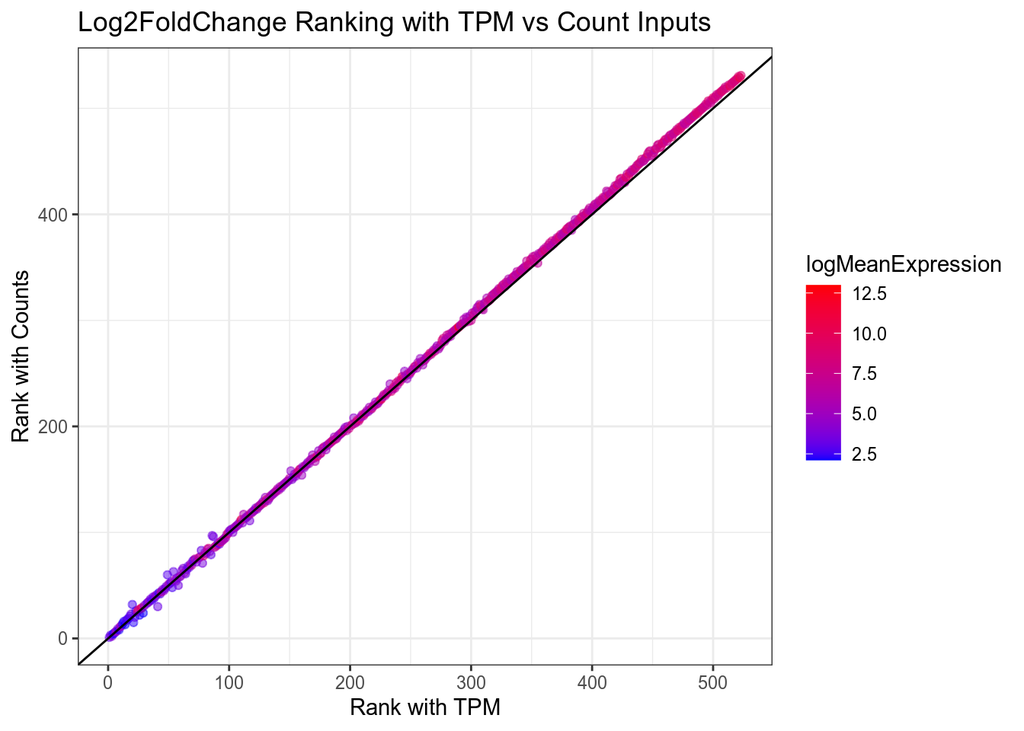

```r
ranking.plot.fn(lfc.rankdiff, "Log2FoldChange")
```

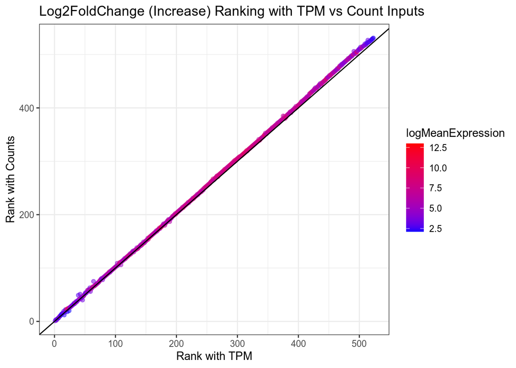

```r
ranking.plot.fn(up.lfc.rankdiff, "Log2FoldChange (Increase)")
```

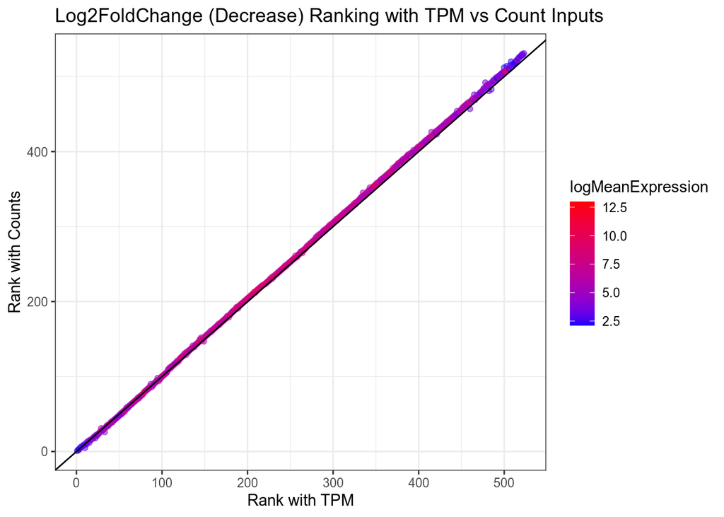

```r
ranking.plot.fn(down.lfc.rankdiff, "Log2FoldChange (Decrease)")
```

## Visualizing DEG ranks II: Rank difference

#### - **x-axis**: expression level (log-baseMean)

#### - **y-axis**: rank difference (rank with TPM - rank with Counts)

#### - **black horizontal lines**: rank with TPM = rank with Counts

#### - **dot color**: average rank

#### - 16 genes were missing in the plots

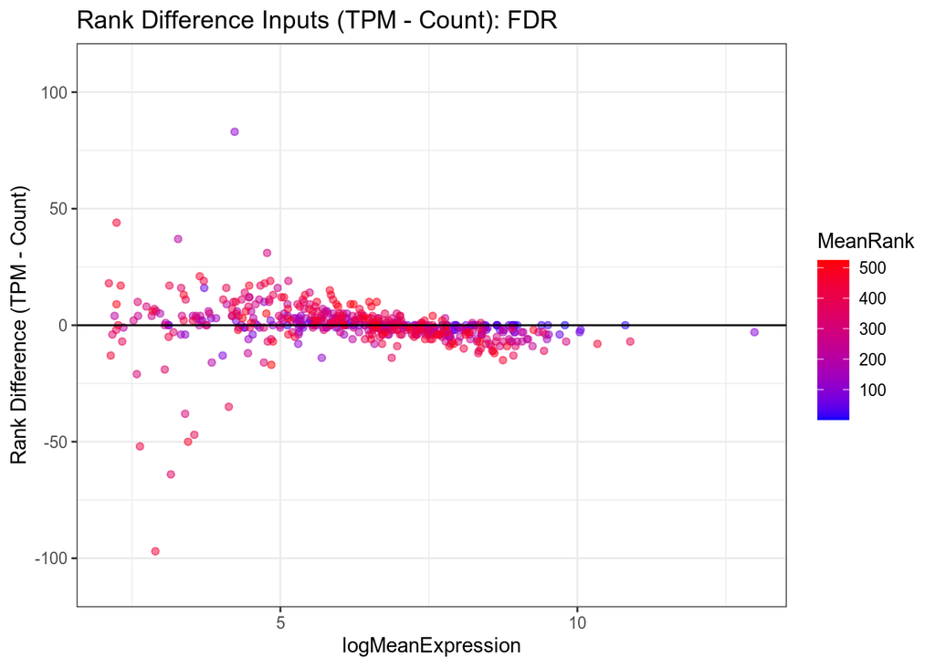

```r
# Set a function plotting the rank difference over the gene expression level
rankdiff.plot.fn <- function(df, rankedby) {

    ggplot(df, aes(x=logMeanExpression, y=RankDiff, color=MeanRank)) +
        geom_point(alpha=0.5) +
        theme_bw() +
        theme(strip.text.x=element_text(size=10)) +
        ylab("Rank Difference (TPM - Count)") +
        ggtitle(paste("Rank Difference Inputs (TPM - Count):", rankedby)) +
        geom_hline(yintercept=0, color="black", size=0.5) + scale_color_gradient(low="blue", high="red") +
        ylim(-110, 110)
}

# Print output plots
rankdiff.plot.fn(fdr.rankdiff, "FDR")
```

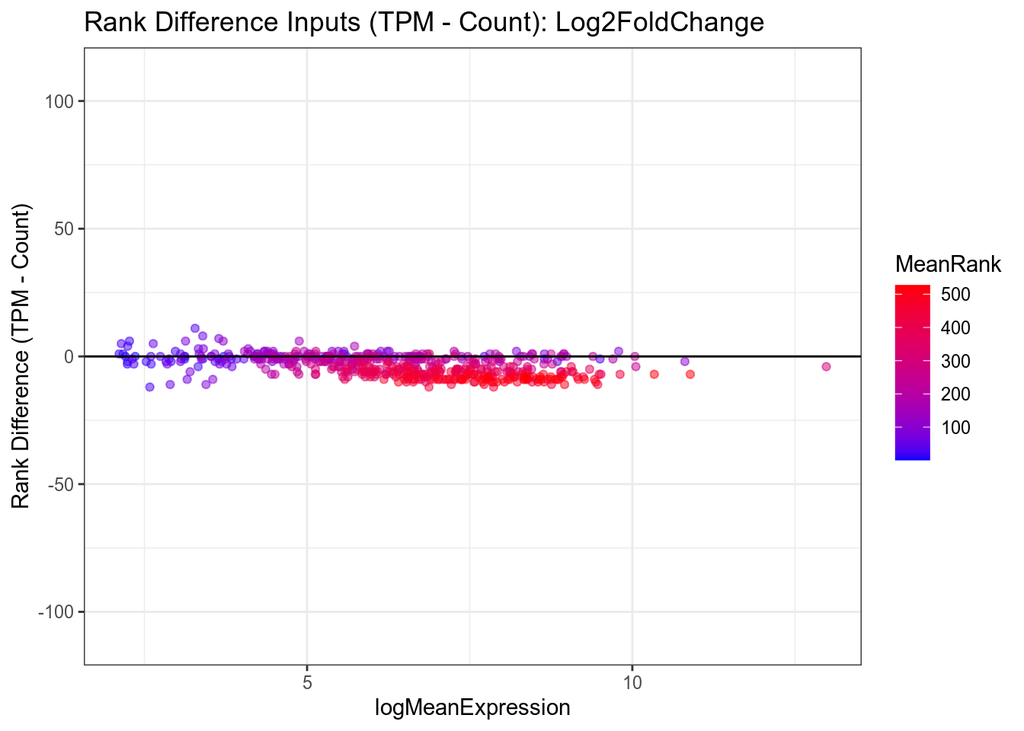

```r
rankdiff.plot.fn(lfc.rankdiff, "Log2FoldChange")
```

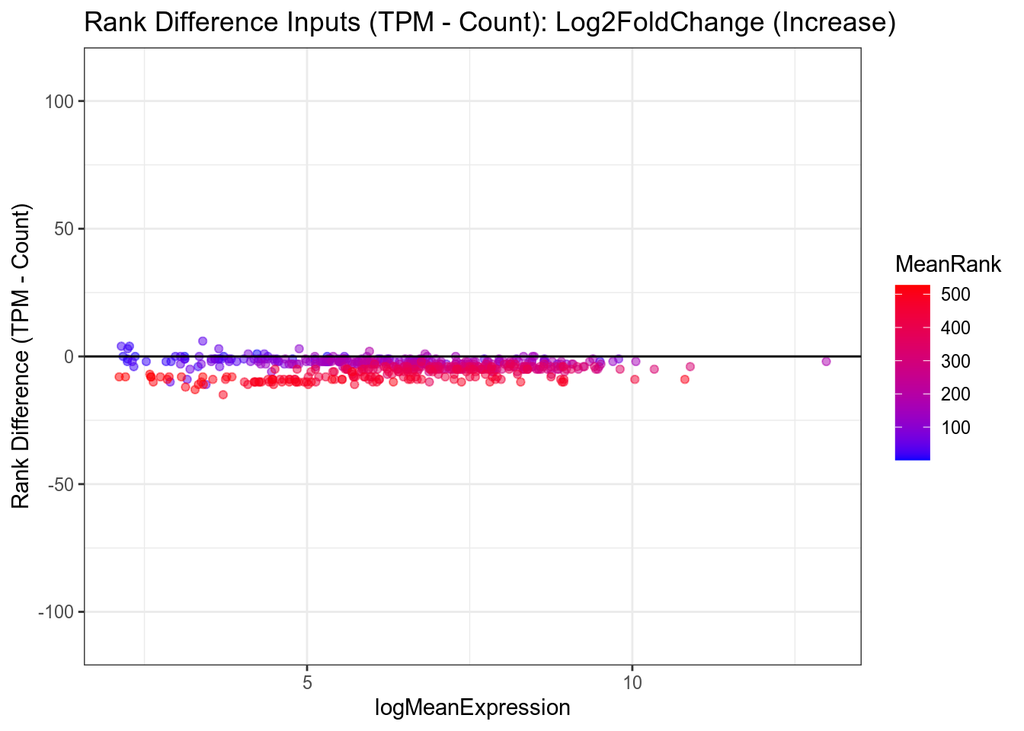

```r
rankdiff.plot.fn(up.lfc.rankdiff, "Log2FoldChange (Increase)")
```

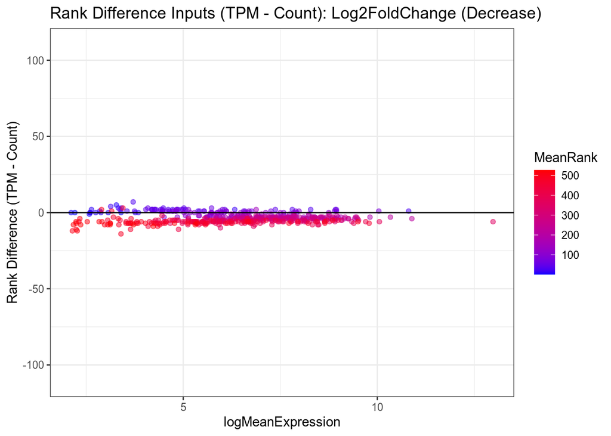

```r
rankdiff.plot.fn(down.lfc.rankdiff, "Log2FoldChange (Decrease)")
```

## Distribution of rank difference

#### - **y-axis**: abs(TPM-Count inputs)

#### - **x-axis**: FDR or log2FoldChange (Increase/Decrease)

#### - **red dashed line**: Rank difference = 25

#### - **blue dashed line**: Rank difference = 10

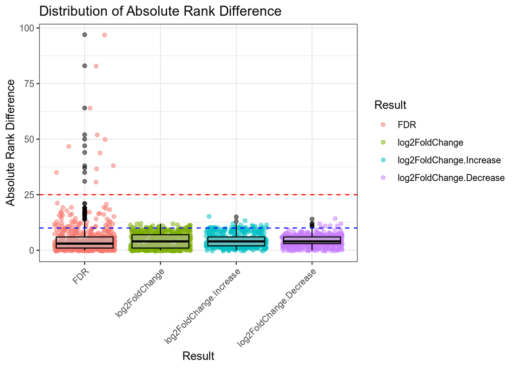

```r
# Create a new data frame storing rank difference by result type
rankdiff.dist <- data.frame(FDR=abs(fdr.rankdiff$RankDiff),
                            log2FoldChange=abs(lfc.rankdiff$RankDiff),
                            log2FoldChange.Increase=abs(up.lfc.rankdiff$RankDiff),
                            log2FoldChange.Decrease=abs(down.lfc.rankdiff$RankDiff)) %>% gather(Result, RankDiff)

# Assine result column as a factor with levels
rankdiff.levels <- c("FDR",
                     "log2FoldChange",
                     "log2FoldChange.Increase",
                     "log2FoldChange.Decrease")

rankdiff.dist$Result <- factor(rankdiff.dist$Result, levels=rankdiff.levels)

# Plot distribution of absolute rank difference
ggplot(rankdiff.dist,
       aes(x=Result, y=RankDiff, color=Result)) +
geom_jitter(alpha=0.5) +
geom_boxplot(alpha=0.5, fill="grey", color="black") +
theme_bw() +
theme(axis.text.x=element_text(angle=45, hjust=1)) +
ggtitle("Distribution of Absolute Rank Difference") +
ylab("Absolute Rank Difference") +
geom_hline(yintercept=c(10, 25),     # depends on your interest
           linetype="dashed",
           color=c("blue", "red"))
```

## Relationship between rank difference and number of transcript versions

#### - **y-axis**: abs(TPM-Count inputs)

#### - **x-axis**: number of transcripts (number of transcript id / gene id)

#### - **dot color**: mean rank

#### - 16 genes were missing in the plots

```r
# Create a data frame storing the number of transcripts by gene id
AnnoDb.ntrans <- AnnoDb %>%
    group_by(ENSEMBL) %>%
    summarize(num.trans=n())

# Set a function adding the number of transcripts by gene id
add.ntrans.fn <- function(df) {

    left_join(df, AnnoDb.ntrans, by=c("Gene"="ENSEMBL"))}

# Create a list storing rankdiff data frames
rankList <- list(fdr.rankdiff,
                 lfc.rankdiff,
                 up.lfc.rankdiff,
                 down.lfc.rankdiff)

# Name the list
names(rankList) <- rankdiff.levels

# Add a column indicating the number of transcripts by gene id to every rankdiff data frame
for (x in rankdiff.levels) {

    rankList[[x]] <- add.ntrans.fn(rankList[[x]])
}


# Explore the edited data frames
summary(rankList)
```

```
##                         Length Class      Mode
## FDR                     11     data.table list
## log2FoldChange          11     data.table list
## log2FoldChange.Increase 11     data.table list
## log2FoldChange.Decrease 11     data.table list
```

```r
head(rankList[[1]])
```

```
##               Gene Input.x Rank.x baseMean.x Input.y Rank.y baseMean.y
## 1: ENSG00000118523     TPM      1  3782.1546  Counts      1  3838.8131
## 2: ENSG00000181104     TPM      2  2460.4827  Counts      2  2498.1179
## 3: ENSG00000163814     TPM      3  1500.9144  Counts      3  1523.3025
## 4: ENSG00000211455     TPM      4 11846.6666  Counts      4 12016.7778
## 5: ENSG00000163762     TPM      5  1895.6825  Counts      5  1919.1263
## 6: ENSG00000138271     TPM      6   526.0495  Counts      6   533.5471
##    logMeanExpression RankDiff MeanRank num.trans
## 1:          8.648495        0        1         1
## 2:          8.218664        0        2         2
## 3:          7.724255        0        3         3
## 4:          9.790042        0        4        13
## 5:          7.956913        0        5         5
## 6:          6.675600        0        6         2
```

```r
head(rankList[[2]])
```

```
##               Gene Input.x Rank.x baseMean.x Input.y Rank.y baseMean.y
## 1: ENSG00000244398     TPM      1  15.010762  Counts      1  15.154500
## 2: ENSG00000248167     TPM      2  14.963658  Counts      3  15.294288
## 3: ENSG00000198796     TPM      3  46.264341  Counts      2  44.935384
## 4: ENSG00000178776     TPM      4   7.009990  Counts      4   7.111688
## 5: ENSG00000263647     TPM      5   6.033026  Counts      5   6.129028
## 6: ENSG00000205277     TPM      6  31.299509  Counts      6  19.797258
##    logMeanExpression RankDiff MeanRank num.trans
## 1:          3.117419        0      1.0         1
## 2:          3.118428       -1      2.5        70
## 3:          4.230215        1      2.5         6
## 4:          2.357626        0      4.0         3
## 5:          2.208004        0      5.0         1
## 6:          3.718393        0      6.0         6
```

```r
head(rankList[[3]])
```

```
##               Gene Input.x Rank.x baseMean.x Input.y Rank.y baseMean.y
## 1: ENSG00000244398     TPM      1   15.01076  Counts      1  15.154500
## 2: ENSG00000248167     TPM      2   14.96366  Counts      3  15.294288
## 3: ENSG00000198796     TPM      3   46.26434  Counts      2  44.935384
## 4: ENSG00000178776     TPM      4    7.00999  Counts      4   7.111688
## 5: ENSG00000205277     TPM      5   31.29951  Counts      5  19.797258
## 6: ENSG00000137673     TPM      6  134.20635  Counts      6 136.082046
##    logMeanExpression RankDiff MeanRank num.trans
## 1:          3.117419        0      1.0         1
## 2:          3.118428       -1      2.5        70
## 3:          4.230215        1      2.5         6
## 4:          2.357626        0      4.0         3
## 5:          3.718393        0      5.0         6
## 6:          5.309492        0      6.0         3
```

```r
head(rankList[[4]])
```

```
##               Gene Input.x Rank.x baseMean.x Input.y Rank.y baseMean.y
## 1: ENSG00000263647     TPM      1   6.033026  Counts      1   6.129028
## 2: ENSG00000271723     TPM      2  19.770937  Counts      2  20.243254
## 3: ENSG00000261408     TPM      3   5.483008  Counts      3   5.565687
## 4: ENSG00000251177     TPM      4   8.961759  Counts      4   9.095538
## 5: ENSG00000205111     TPM      5   8.951564  Counts      6   8.565669
## 6: ENSG00000273540     TPM      6   6.489977    <NA>     NA         NA
##    logMeanExpression RankDiff MeanRank num.trans
## 1:          2.208004        0      1.0         1
## 2:          3.397610        0      2.0         4
## 3:          2.112133        0      3.0         3
## 4:          2.603395        0      4.0         1
## 5:          2.582819       -1      5.5         4
## 6:                NA       NA       NA         5
```

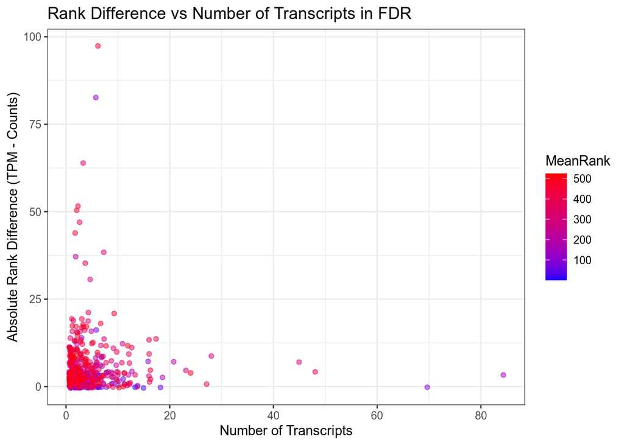

```r
# Set a function plotting rank difference vs number of transcripts
rank.ntrans.plot.fn <- function(df, title) {

    ggplot(df, aes(x=num.trans, y=abs(RankDiff), color=MeanRank)) +
        geom_jitter(alpha=0.5) +
        theme_bw() +
        ggtitle(paste("Rank Difference vs Number of Transcripts in", title)) +
        xlab("Number of Transcripts") +
        ylab("Absolute Rank Difference (TPM - Counts)") + scale_color_gradient(low="blue", high="red")
}

# Print the plots
rank.ntrans.plot.fn(rankList[[rankdiff.levels[1]]], "FDR")
```

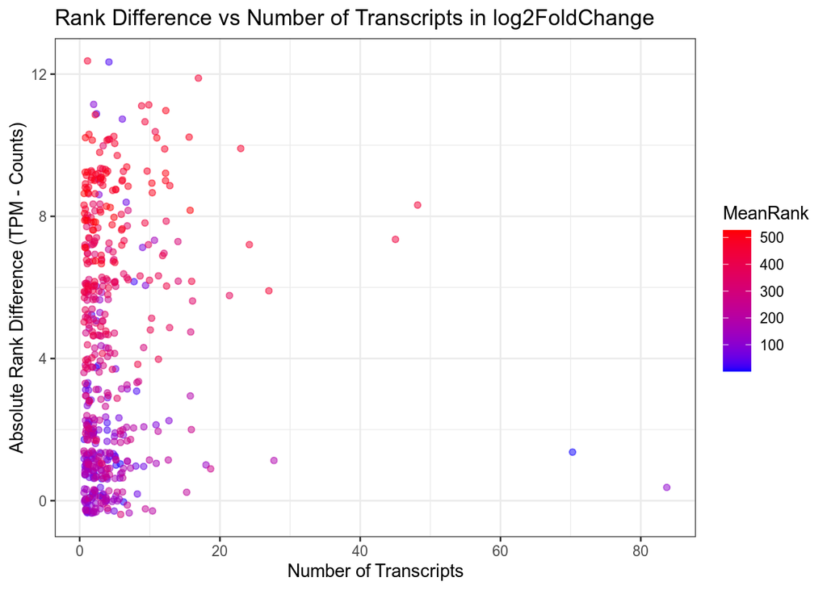

```r
rank.ntrans.plot.fn(rankList[[rankdiff.levels[2]]], "log2FoldChange")
```

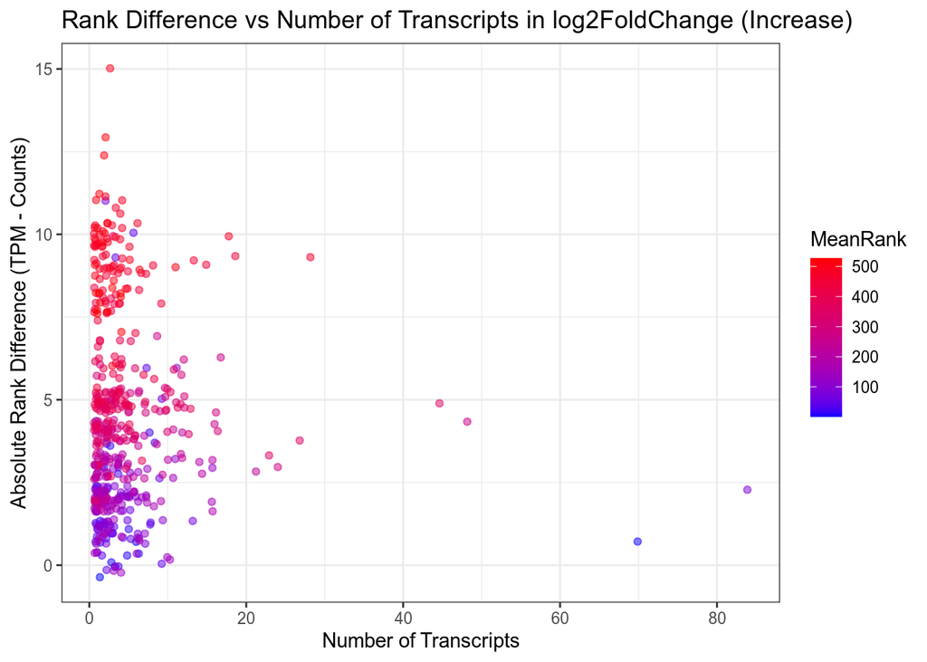

```r
rank.ntrans.plot.fn(rankList[[rankdiff.levels[3]]], "log2FoldChange (Increase)")
```

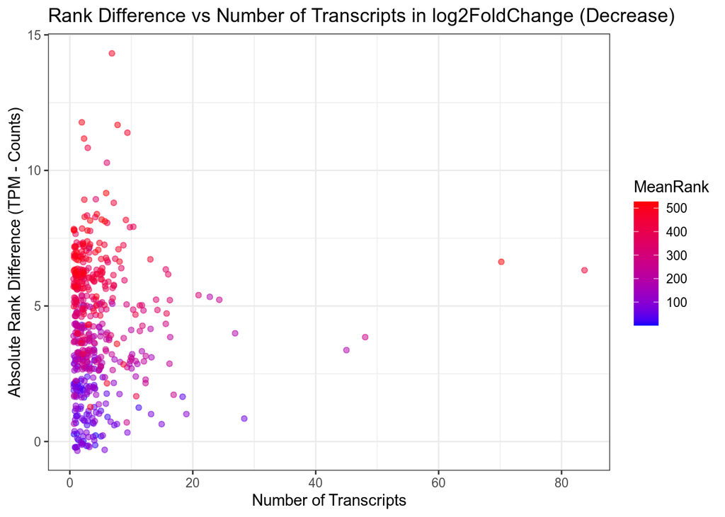

```r
rank.ntrans.plot.fn(rankList[[rankdiff.levels[4]]], "log2FoldChange (Decrease)")
```

## Finding genes having large difference in rankings

```r
# Initialize a list storing rankdiff genes
large.rankdiff <- rankList

# Assign a vector storing minimum (thresholds) rankdiff for filtering large rankdiff genes
rankdiff.thr <- c(25, 10, 10, 10)

names(rankdiff.thr) <- rankdiff.levels

for (x in rankdiff.levels) {

    # Filter out observations below the rankdiff thresholds
    large.rankdiff[[x]] <- subset(rankList[[x]],
                                      abs(RankDiff) > rankdiff.thr[x])

}

# Explore the filtered genes
summary(large.rankdiff)
```

```
##                         Length Class      Mode
## FDR                     11     data.table list
## log2FoldChange          11     data.table list
## log2FoldChange.Increase 11     data.table list
## log2FoldChange.Decrease 11     data.table list
```

```r
dim(large.rankdiff[[rankdiff.levels[1]]])
```

```
## [1] 11 11
```

```r
dim(large.rankdiff[[rankdiff.levels[2]]])
```

```
## [1] 11 11
```

```r
dim(large.rankdiff[[rankdiff.levels[3]]])
```

```
## [1] 10 11
```

```r
dim(large.rankdiff[[rankdiff.levels[4]]])
```

```
## [1]  6 11
```

```r
head(large.rankdiff[[rankdiff.levels[1]]])
```

```
##               Gene Input.x Rank.x baseMean.x Input.y Rank.y baseMean.y
## 1: ENSG00000198796     TPM    150   46.26434  Counts     67   44.93538
## 2: ENSG00000205002     TPM    228   18.90802  Counts    191   15.24945
## 3: ENSG00000081051     TPM    287   21.38192  Counts    325   16.94728
## 4: ENSG00000049249     TPM    300   85.49066  Counts    269   66.43793
## 5: ENSG00000184697     TPM    315   15.98649  Counts    379   14.99418
## 6: ENSG00000233436     TPM    360   23.81858  Counts    407   22.06726
##    logMeanExpression RankDiff MeanRank num.trans
## 1:          4.230215       83    108.5         6
## 2:          3.278380       37    209.5         2
## 3:          3.396371      -38    306.0         7
## 4:          4.776680       31    284.5         5
## 5:          3.156302      -64    347.0         3
## 6:          3.551117      -47    383.5         3
```

```r
head(large.rankdiff[[rankdiff.levels[2]]])
```

```
##               Gene Input.x Rank.x  baseMean.x Input.y Rank.y  baseMean.y
## 1: ENSG00000205111     TPM     20    8.951564  Counts     32    8.565669
## 2: ENSG00000205002     TPM     41   18.908019  Counts     30   15.249451
## 3: ENSG00000197632     TPM     49   12.428928  Counts     60   11.327244
## 4: ENSG00000189127     TPM     86   21.235229  Counts     97   20.289263
## 5: ENSG00000114850     TPM    441 4215.489292  Counts    452 4276.812804
## 6: ENSG00000265241     TPM    446 8585.145057  Counts    457 8705.643678
##    logMeanExpression RankDiff MeanRank num.trans
## 1:          2.582819      -12     26.0         4
## 2:          3.278380       11     35.5         2
## 3:          2.895500      -11     54.5         6
## 4:          3.446166      -11     91.5         2
## 5:          8.756823      -11    446.5         9
## 6:          9.467921      -11    451.5         9
```

```r
head(large.rankdiff[[rankdiff.levels[3]]])
```

```
##               Gene Input.x Rank.x baseMean.x Input.y Rank.y baseMean.y
## 1: ENSG00000189127     TPM     64   21.23523  Counts     75   20.28926
## 2: ENSG00000113946     TPM    468  206.34368  Counts    479  203.15970
## 3: ENSG00000258102     TPM    471   40.11455  Counts    482   39.19696
## 4: ENSG00000164188     TPM    482  100.48741  Counts    493  101.10937
## 5: ENSG00000271271     TPM    487   58.88226  Counts    498   59.74454
## 6: ENSG00000164647     TPM    491   27.24260  Counts    506   27.22627
##    logMeanExpression RankDiff MeanRank num.trans
## 1:          3.446166      -11     69.5         2
## 2:          5.729851      -11    473.5         3
## 3:          4.089550      -11    476.5         4
## 4:          5.017559      -11    487.5         4
## 5:          4.485875      -11    492.5         2
## 6:          3.710047      -15    498.5         3
```

```r
head(large.rankdiff[[rankdiff.levels[4]]])
```

```
##               Gene Input.x Rank.x baseMean.x Input.y Rank.y baseMean.y
## 1: ENSG00000095587     TPM    415  88.490210  Counts    426  85.958306
## 2: ENSG00000259479     TPM    465  26.297032  Counts    476  23.827729
## 3: ENSG00000081051     TPM    478  21.381916  Counts    492  16.947281
## 4: ENSG00000143028     TPM    500   6.053198  Counts    512   4.970562
## 5: ENSG00000197106     TPM    503   6.311283  Counts    514   6.202051
## 6: ENSG00000166741     TPM    508   6.966017  Counts    520   5.423809
##    logMeanExpression RankDiff MeanRank num.trans
## 1:          4.878774      -11    420.5         3
## 2:          3.643121      -11    470.5         9
## 3:          3.396371      -14    485.0         7
## 4:          2.144583      -12    506.0         2
## 5:          2.242018      -11    508.5         2
## 6:          2.269847      -12    514.0         8
```

## Summarizing up/down DEGs with an upset plot

#### - **red bar**: input type

#### - **blue bar**: directionality of gene expression change

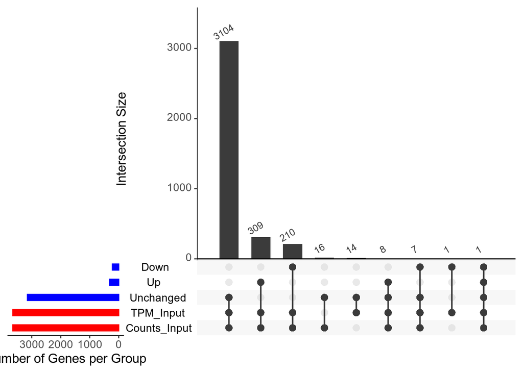

```r
# Set a function cleaning data to generate upset plots
upset.input.fn <- function(df) {

    df <- df %>%

        # Filter genes with valid padj
        filter(!is.na(padj)) %>%

        mutate(Up=ifelse(FDR == FDRv[1] & log2FoldChange > 0, Gene, ""), # What are upregulated genes?

               Down=ifelse(FDR == FDRv[1] & log2FoldChange < 0, Gene, ""),  # What are downregulated genes?

               Unchanged=ifelse(FDR == FDRv[2], Gene, ""),   # What are unchanged genes?

               TPM_Input=ifelse(Input == "TPM", Gene, ""),   # What are the genes from TPM input?

               Counts_Input=ifelse(Input == "Counts", Gene, ""))   # What are the genes from Counts input?

    # Create a list storing groups of interest
    upsetInput <- list(Up=df$Up,
                       Down=df$Down,
                       Unchanged=df$Unchanged,
                       TPM_Input=df$TPM,
                       Counts_Input=df$Counts)

    return(upsetInput)

}

upsetList <- upset.input.fn(rbind(both.df))


# Create the upset plot
upset(fromList(upsetList),
      sets=names(upsetList),   # What group to display
      sets.x.label="Number of Genes per Group",
      order.by="freq",
      point.size=3,
      sets.bar.color=c("red", "red","blue", "blue", "blue"),
      text.scale = 1.5, number.angles=30)
```